# Look at multiple regions: first, grid using dggridR

First, I had to download dggridR. Note that the version that is installed using install.packages() was not updated to work with this version of R. Therefore, I downloaded directly from GitHub using:

library(devtools) #Use `install.packages('devtools')` if need be install_github(‘r-barnes/dggridR’, vignette=TRUE)

on November 23, 2020.

```r
library(dggridR)
library(data.table)
library(rgdal)
library(raster)
library(sp)
library(rnaturalearth)
library(rnaturalearthdata)
library(rgeos)
library(taxize) #standardizing names
library(googledrive)
```

Moving forward, I plan to use data directly from FishGlob.

November 21, 2021

```r
drive_download("NEUS_clean.csv",
               overwrite = T)
```

[output not shown]

```
1: zjk5@scarletmail.rutgers.edu
```

```r
1
```

```
Auto-refreshing stale OAuth token.
File downloaded:
• NEUS_clean.csv <id: 1TeKdTLeCVjtp7OpmZpgtxVWaBafywpak>
Saved locally as:
• NEUS_clean.csv
```

```r
neus <- fread("NEUS_clean.csv")

file.remove("NEUS_clean.csv")
```

```
[1] TRUE
```

```r
setkey(neus)

#spring only
neus.spring <- neus[season == "Spring",]

# Get unique lat lon values in the data table
unique_neus_latlon <- unique(neus.spring[,.(latitude, longitude)])
unique_neus_latlon.sf <- unique_neus_latlon

#make lat lon coordinates into polygon
coordinates(unique_neus_latlon.sf) <- ~latitude + longitude
unique_neus_latlon.sf@proj4string <- crs("+proj=longlat +datum=WGS84 +no_defs +ellps=WGS84 +towgs84=0,0,0")

saveRDS(unique_neus_latlon, "unique_neus_latlon.rds") #save list of lat lon coordinates
```

Visualize NEUS sampling sites

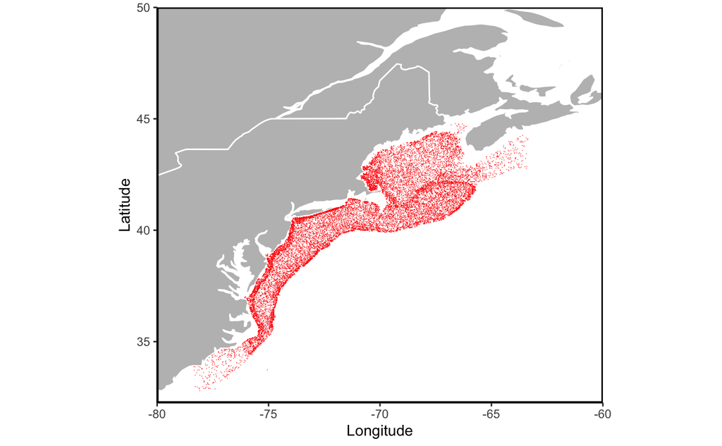

```r
#open RDS if already saved
#unique_neus_latlon <- readRDS("/Users/zoekitchel/Documents/grad school/Rutgers/Repositories/trawl_spatial_turnover/unique_neus_latlon.RData")

#plot north america
world <- ne_countries(scale = "medium", returnclass = "sp")

world_ext <- extent(-80, -60,30, 50)

north_america_spdf <- crop(world, world_ext)

north_america_df <- fortify(north_america_spdf)
(na_outline <- ggplot(north_america_df, aes(long, lat, group = group)) +
  geom_polygon(color = "white", fill = "grey") +
  labs(x = "Longitude", y = "Latitude") +
  coord_equal() +
  theme_classic() +
  scale_x_continuous(expand = c(0,0)) +
  scale_y_continuous(expand = c(0,0)) +
  theme(panel.border = element_rect(color = "black", fill = NA, size = 1)) +
 geom_point(unique_neus_latlon, mapping = aes(longitude, latitude), inherit.aes = FALSE, shape = 18, size = 0.001, color = "red") +
  coord_equal())
```

Setting up hexagonal grid cells with dggridR (package that makes grid cells)

```r
dggs <- dgconstruct(spacing = 111, metric = T, resround = 'nearest') #make cells with 111km spacing for whole planet
```

```
Resolution: 8, Area (km^2): 7774.20548276313, Spacing (km): 87.0821287828498, CLS (km): 99.4910857271796
```

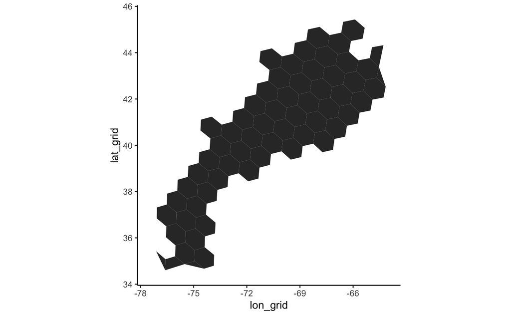

```r
unique_neus_latlon[,cell := dgGEO_to_SEQNUM(dggs, longitude, latitude)] #get corresponding grid cells for NEUS trawl

#centers of cells
neus_cellcenters <- dgSEQNUM_to_GEO(dggs, unique_neus_latlon[,cell])

#linking cell centers to unique_neus_latlon
unique_neus_latlon[,LON_CENTER := neus_cellcenters$lon_deg][,LAT_CENTER := neus_cellcenters$lat_deg]

#link centers back to main data table

neus.spring_grid <- merge(neus.spring, unique_neus_latlon, by = c("latitude", "longitude"))


#number of tows in each cell by season for all years
towcount <- unique_neus_latlon[, list(Freq = .N), by = list(cell)]

#get the grid cell boundary for cells which had trawls
grid_neus <- dgcellstogrid(dggs, unique_neus_latlon[,cell], frame = T, wrapcells = F)
colnames(grid_neus) <- c("lon_grid", "lat_grid", "order", "hole", "piece", "group", "cell")

#merge polygon outlines with all haul coordinates within for each season
grid_neus <- merge(grid_neus, unique_neus_latlon, by = "cell") #this takes a while

#$region <- as.factor(grid_neus$region)


#spring
ggplot(data = grid_neus, aes(x = lon_grid, y = lat_grid, group = cell)) +
  geom_polygon() +
    lims(x = c(-77.5,-64), y = c(34.5,45.5)) +
  coord_quickmap() +
  theme_classic()
```

```r
saveRDS(grid_neus, "grid_neus.RData")
```

Trying to plot with grid overlaying

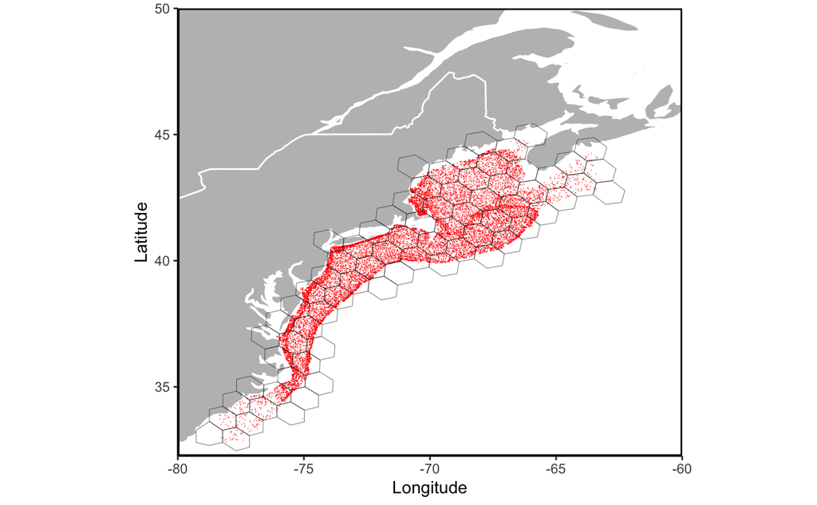

```r
na_outline +
   geom_polygon(grid_neus, mapping = aes(x = lon_grid,y = lat_grid, group = cell), inherit.aes = FALSE, color = "black", fill = NA, size = 0.1)

ggsave(filename = "neus_grid_cells_spacing_111.pdf")
```

```r
NA
```

Cleaning up NEUS data

```r
neus.spring_grid.clean <- neus.spring_grid[rank == "Species"]
```

Now, we’ll overlay grid cells onto this list of tows using LAT and LON and gridrr package

[figure not shown]

```r
year_grid <- data.table(table(neus.spring_grid.clean$cell, neus.spring_grid.clean$year))

#full matrix of year x grid x  cell
cell_numbers <- unique(neus.spring_grid.clean$cell)
years <- unique(neus.spring_grid.clean$year)
seasons <- unique(neus.spring_grid.clean$region)

cells_cross_years_cross_region <- data.table(expand.grid(cell = cell_numbers, year = years, region = seasons))

observations <- unique(neus.spring_grid.clean[,.N,by = c("year","cell")])

#merge possible cell year region combinations with actual observations
neus_cell_data_nodata <- observations[cells_cross_years_cross_region, on = .(year, cell)]

#new pres/abs column
neus_cell_data_nodata[,pres := ifelse(is.na(N), 0, 1)]

#which grid cells are sampled in which years?
ggplot(neus_cell_data_nodata, aes(as.factor(year), as.factor(cell))) +
  geom_tile(aes(fill = factor(pres)), color = "grey", size = 0.01) +
#  facet_wrap(~region, scales="free") +
  scale_fill_manual(values = c("white", "black"), breaks = c(0,1), labels = c("No Data", "Data")) +
  labs(x = "Year", y = "Cell") +
  theme(legend.title = element_blank(),
        axis.text.y = element_text(size = 4),
        axis.text.x = element_text(size = 5, angle = 90, vjust = 0.5),
        strip.text.x = element_text(size = 10),
        axis.ticks = element_blank())

ggsave(filename = "neus_data_availability.jpg", path = "/Users/zoekitchel/Documents/grad school/Rutgers/Repositories/trawl_spatial_turnover/data/USA-NEUS/")
```

Delete cells that aren’t sampled regularly (missing more than 2 years from 1972-2019):

- 6664: sampled sporadically in spring and fall
- 6583: sampled sporadically in spring and fall
- 6576: sampled sporadically in spring and fall
- 6575: sampled sporadically in spring and fall
- 6571: sampled sporadically in spring and fall
- 6076: missing a few observations in spring and fall, dump fall keep spring
- 5831: only sampled once in fall, never in spring
- 5507: sampled sporadically in fall, keep for spring only
- 5347: sampled sporadically in spring and fall, keep for spring only
- 5346: sampled sporadically in spring and fall
- 5265: missing a few observations in spring and fall, keep for spring only
- 5102: sampled sporadically in spring and fall
- 5022: missing a few observations in spring and fall, keep for spring only
- 4942:sampled sporadically in spring and fall
- 4941: sampled sporadically in spring and fall

Years with issues to look into:

- 2017 fall
- 1972, 1975, 1977, 2014 spring